Logistic regression

```r
library(dplyr)
```

```r
library(ggplot2)
alc <- read.csv("alc.csv")
print(alc)
```

[output not shown]

[output cut: 1469 more lines]

# Here is the data used in this week’s analysis. It is data related to student achievemnt in two Portuguese schools. This data includes student grades, demographic, social and school related features. The data was collected using school reports and questionnaires.

# For the variables I will be using for my analysis I will choose the following four: sex, age, activities and freetime. My personal hypothesis is that males will consume more alcohol than females, age increasing correlates with the increase in alcohol consumption in this population and then I am unsure about activites. I don’t really have a guess as to how it will effect alcohol consumption or be related to it. I also think that alcohol consumption might increase with freetime.

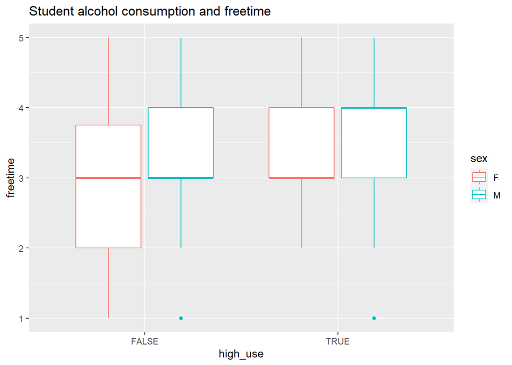

```r
g1 <- ggplot(alc, aes(x = high_use, y = freetime, col = sex))
g1 + geom_boxplot() + ylab("freetime") + ggtitle("Student alcohol consumption and freetime")
```

```r
alc %>% group_by(activities, high_use) %>% summarise(count = n())
```

```
## # A tibble: 4 x 3
## # Groups:   activities [2]
##   activities high_use count
##   <chr>      <lgl>    <int>
## 1 no         FALSE      120
## 2 no         TRUE        59
## 3 yes        FALSE      139
## 4 yes        TRUE        52
```

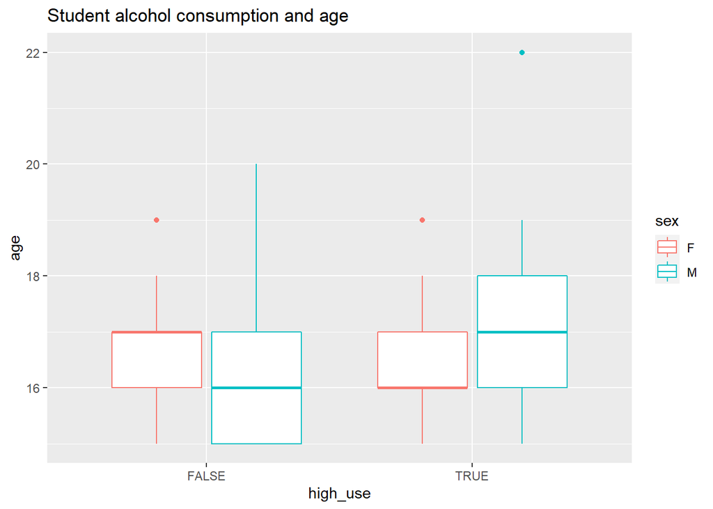

```r
g3 <- ggplot(alc, aes(x = high_use, y = age, col = sex))
g3 + geom_boxplot() + ggtitle("Student alcohol consumption and age") + ylab("age")
```

# The first boxplot is student alcohol consumption and freetime. There seems to be a an outlier in high use with low freetime and likewise in low use with low freetime. According to this there might be a relationship with alcohol consumption and freetime atleast for females, but there seems to be no significant difference for males.

#Then we have a cross tabulation of activities and high alcohol consumption. We can see that there were sligthly more people with higher alcohol consumption among people with no activites and the percentage of people with high alcohol consumption in people with no activites was also higher. Therefore, there might be a statistical relationship between having activites and alcohol consumption.

#The third graph is also a boxplot this time with student alcohol consumption and age. There are outliers in people with high alcohol consumption among males and females. There is also an outlier in the low alcohol consumption group on the female side, but not on the male side. There seems to be a potential relationship between age and alcohol consumption based on this plot.

```r
m <- glm(high_use ~ freetime + activities + sex + age, data = alc, family = "binomial")
summary(m)
```

```
##
## Call:
## glm(formula = high_use ~ freetime + activities + sex + age, family = "binomial",
##     data = alc)
##
## Deviance Residuals:
##     Min       1Q   Median       3Q      Max
## -1.5085  -0.8457  -0.6611   1.1868   2.1484
##
## Coefficients:
##               Estimate Std. Error z value Pr(>|z|)
## (Intercept)   -5.30557    1.73720  -3.054 0.002257 **
## freetime       0.30441    0.12548   2.426 0.015268 *
## activitiesyes -0.40662    0.24002  -1.694 0.090241 .
## sexM           0.86104    0.24403   3.528 0.000418 ***
## age            0.19336    0.09988   1.936 0.052885 .
## ---
## Signif. codes:  0 '***' 0.001 '**' 0.01 '*' 0.05 '.' 0.1 ' ' 1
##
## (Dispersion parameter for binomial family taken to be 1)
##
##     Null deviance: 452.04  on 369  degrees of freedom
## Residual deviance: 423.40  on 365  degrees of freedom
## AIC: 433.4
##
## Number of Fisher Scoring iterations: 4
```

```r
coef(m)
```

```
##   (Intercept)      freetime activitiesyes          sexM           age
##    -5.3055743     0.3044065    -0.4066241     0.8610394     0.1933607
```

```r
OR <- coef(m) %>% exp
CI <- confint(m) %>% exp
cbind(OR, CI)
```

```
##                        OR        2.5 %    97.5 %
## (Intercept)   0.004963846 0.0001539286 0.1423453
## freetime      1.355820025 1.0633744995 1.7410289
## activitiesyes 0.665894423 0.4144476790 1.0636972
## sexM          2.365618184 1.4721433120 3.8386581
## age           1.213320375 0.9992506713 1.4797392
```